# 2_google_trend_analysis

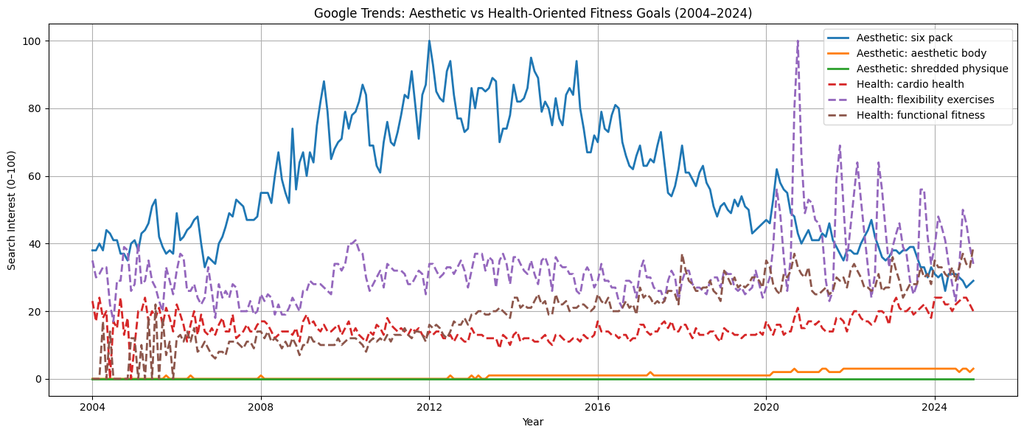

```python
from pytrends.request import TrendReq
import pandas as pd
import matplotlib.pyplot as plt

# Start PyTrends session
pytrends = TrendReq(hl='en-US', tz=360)

# Batch A1: Aesthetics-focused
aesthetic_terms = ["six pack", "aesthetic body", "shredded physique", "fitness model workout", "how to get ripped"]

# Batch H1: Health-focused
health_terms = ["cardio health", "flexibility exercises", "functional fitness", "cardio time", "longevity fitness"]

# Run aesthetic terms
pytrends.build_payload(aesthetic_terms, timeframe='2004-01-01 2024-12-31')
aesthetic_df = pytrends.interest_over_time().drop(columns=['isPartial'])

# Run health terms
pytrends.build_payload(health_terms, timeframe='2004-01-01 2024-12-31')
health_df = pytrends.interest_over_time().drop(columns=['isPartial'])

# Save for later if needed
aesthetic_df.to_csv("../data/google_trends_aesthetic.csv")
health_df.to_csv("../data/google_trends_health.csv")

# Plot trends together
plt.figure(figsize=(14,6))

# Plot top 3 from each for clarity
for col in ["six pack", "aesthetic body", "shredded physique"]:
    plt.plot(aesthetic_df.index, aesthetic_df[col], label=f"Aesthetic: {col}", linewidth=2)

for col in ["cardio health", "flexibility exercises", "functional fitness"]:
    plt.plot(health_df.index, health_df[col], label=f"Health: {col}", linestyle="--", linewidth=2)

plt.title("Google Trends: Aesthetic vs Health-Oriented Fitness Goals (2004–2024)")
plt.xlabel("Year")
plt.ylabel("Search Interest (0–100)")
plt.legend()
plt.grid(True)
plt.tight_layout()
plt.savefig("../visuals/google_trends_aesthetics_vs_health.png", dpi=300)
plt.show()
```

## 📊 Google Trends Analysis: Aesthetics vs Health in Fitness (2004–2024)

This chart compares public interest over time for two categories of fitness goals:

- **Aesthetics-focused**: "six pack", "aesthetic body", "shredded physique", "fitness model workout", "how to get ripped"
- **Health-focused**: "cardio health", "flexibility exercises", "functional fitness", "cardio time", "longevity fitness"

### 🔍 Key Insights:

1. **Dominance of Aesthetic Goals**:
   - "Six pack" searches far outpace all others, especially during 2010–2018, showing how **aesthetics have historically led public interest** in fitness.
   - Seasonal peaks indicate heightened visual motivation around summer months or new year goals.
2. **Low Visibility of Health-Centric Terms**:
   - Terms like "cardio health" and "longevity fitness" remain consistently low, suggesting **preventive health and long-term wellness are underprioritized** in search behavior.
3. **Rise of Functional Fitness & Flexibility (Post-2020)**:
   - "Flexibility exercises" show a **notable rise during and after the COVID-19 pandemic** — possibly linked to at-home workout trends and a growing appreciation for mobility.
   - This could reflect a *micro-shift* in public awareness toward functional, longevity-oriented fitness — though not enough to challenge aesthetic dominance.

### 💡 Interpretation:

This insight ties directly into the next section of the project: **the rise of performance-enhancing drug (PED) culture**, where shortcuts to extreme physiques are increasingly normalized — regardless of the cost.

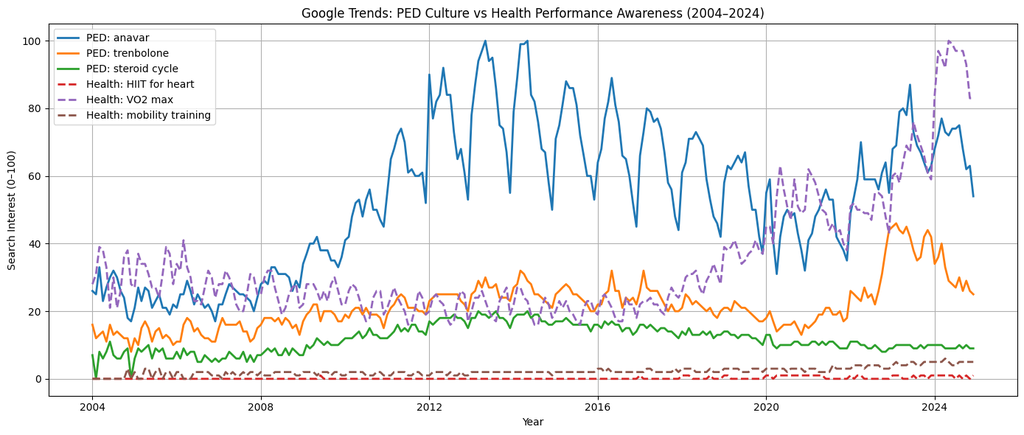

```python
from pytrends.request import TrendReq
import pandas as pd
import matplotlib.pyplot as plt

# Initialize PyTrends
pytrends = TrendReq(hl='en-US', tz=360)

# A2: Steroid/PED keywords
a2_terms = ["anavar", "trenbolone", "blast and cruise", "steroid cycle", "ripped fast"]

# H2: Longevity & health-performance keywords
h2_terms = ["HIIT for heart", "mobility training", "heart rate zones", "walk for health", "VO2 max"]

import time

# Get A2 data
pytrends.build_payload(a2_terms, timeframe='2004-01-01 2024-12-31')
a2_df = pytrends.interest_over_time().drop(columns=['isPartial'])

# Introduce a delay to avoid TooManyRequestsError
time.sleep(10)

# Get H2 data
pytrends.build_payload(h2_terms, timeframe='2004-01-01 2024-12-31')
h2_df = pytrends.interest_over_time().drop(columns=['isPartial'])

# Save if needed
a2_df.to_csv("../data/google_trends_steroids.csv")
h2_df.to_csv("../data/google_trends_health_advanced.csv")

# Plot
plt.figure(figsize=(14,6))

# Plot top A2 and H2 terms for visibility
for col in ["anavar", "trenbolone", "steroid cycle"]:
    plt.plot(a2_df.index, a2_df[col], label=f"PED: {col}", linewidth=2)

for col in ["HIIT for heart", "VO2 max", "mobility training"]:
    plt.plot(h2_df.index, h2_df[col], label=f"Health: {col}", linestyle='--', linewidth=2)

plt.title("Google Trends: PED Culture vs Health Performance Awareness (2004–2024)")
plt.xlabel("Year")
plt.ylabel("Search Interest (0–100)")
plt.legend()
plt.grid(True)
plt.tight_layout()
plt.savefig("../visuals/google_trends_ped_vs_advanced_health.png", dpi=300)
plt.show()
```

## 💉 Google Trends: PED Culture in Fitness (2004–2024)

This chart examines search interest in traditional performance-enhancing drugs (PEDs) such as:

- **Anavar**
- **Trenbolone**
- **Steroid cycle**

These substances are widely known within bodybuilding communities and are often associated with rapid muscle gain and extreme physique enhancement.

### ⚠️ Cultural Implication:

The normalization of steroid-related terms online suggests a broader **acceptance of chemical enhancement** in the pursuit of aesthetics — moving beyond elite bodybuilding into the mainstream. It's no longer niche; it's aspirational for many.

This rise in PED interest lays the foundation for even more accessible, experimental alternatives — which brings us to the next section: **SARMs.**

[figure not shown]

```python
# A3: SARMs & experimental PEDs
sarms_terms = ["sarms", "ostarine", "rad 140", "lgd", "mk 677"]

pytrends.build_payload(sarms_terms, timeframe='2004-01-01 2024-12-31')
sarms_df = pytrends.interest_over_time().drop(columns=['isPartial'])

# Save for backup
sarms_df.to_csv("../data/google_trends_sarms.csv")

# Plot top SARMs terms
plt.figure(figsize=(14,6))

for col in sarms_df.columns[:4]:  # Limit to top 4 for visibility
    plt.plot(sarms_df.index, sarms_df[col], label=f"SARM: {col}", linewidth=2)

plt.title("Google Trends: SARMs (Selective Androgen Receptor Modulators) Popularity (2004–2024)")
plt.xlabel("Year")
plt.ylabel("Search Interest")
plt.legend()
plt.grid(True)
plt.tight_layout()
plt.savefig("../visuals/google_trends_sarms.png", dpi=300)
plt.show()
```

## 🧪 Google Trends: SARMs – The New Wave of Performance Enhancement (2004–2024)

This chart explores the rising popularity of **SARMs (Selective Androgen Receptor Modulators)** — compounds such as:

- **sarms**
- **ostarine**
- **rad 140**
- **LGD** *(Ligandrol)*

Marketed as “safer” or “legal” alternatives to steroids, SARMs have become especially popular among teens and recreational lifters seeking dramatic results without the stigma or invasiveness of traditional PEDs.

### 🔍 Key Insights:

1. The term “sarms” has seen **a dramatic post-2015 spike**, peaking during 2019–2022 — aligning with their boom on TikTok, YouTube, and Reddit.
2. Compound-specific interest in “ostarine”, “rad 140”, and “LGD” highlights growing awareness, usage, and experimentation in mainstream fitness spaces.
3. The trend mimics supplement cycles — **quick spikes, persistent baseline curiosity**, and recurring engagement — suggesting a shift in how these compounds are perceived.

### 🧠 Implication:

- SARMs are blurring the line between “natural” and “enhanced,” especially in online communities that market them with minimal transparency.
- Despite their **legal ambiguity and lack of FDA approval**, they’re being normalized — even among casual gym-goers and young audiences.

> We're witnessing **a decentralization of enhancement culture** — it's no longer underground or elite, but repackaged for mass consumption.

### ➡️ What’s Next:

Having examined the **evolution of gym culture through pricing, PEDs, and SARMs**, we now explore its **real-world impact**.

The next section turns toward the most sobering outcome of this trend:

> **The growing list of fitness influencers and athletes who died young — many with direct or indirect ties to performance-enhancing drugs.**

## 🔚 Section 4: Influencer Mortality – The Real Cost of PED Culture

```python
file_path = "../data/influencer_death.csv"

# Try reading with a more flexible separator handling quotes and colon markers
influencer_df = pd.read_csv(file_path, sep=",", on_bad_lines='skip', engine='python')

# Show the first few rows
influencer_df.head()
```

|  | Full Name | Date of Birth | Date of Death | Age at Death | Nationality | Profession/Prominence | PED Involvement | Cause of Death | Notable Public/Social Media Presence |
| --- | --- | --- | --- | --- | --- | --- | --- | --- | --- |
| 0 | Mohammed Benaziza | c.1959 | 1992-10-04 | 33 | Algerian | Professional bodybuilder | Confirmed steroid and diuretic use:contentRefe... | Heart failure after contest (extreme dehydrati... | Nicknamed 'Killer of Giants'; died hours after... |
| 1 | Andreas Münzer | 1964-10-25 | 1996-03-14 | 31 | Austrian | Professional bodybuilder | Confirmed steroid and diuretic use:contentRefe... | Multiple organ failure due to steroid and diur... | Featured in bodybuilding magazines; cautionary... |
| 2 | Eddie Guerrero | 1967-10-09 | 2005-11-13 | 38 | American | Professional wrestler (WWE superstar) | Suspected PED use (history of anabolic steroid... | Heart failure due to arteriosclerotic heart di... | Hall of Fame wrestler; early death prompted WW... |
| 3 | Ana Carolina Reston | June 1985 | 2006-11-14 | 21 | Brazilian | Fashion model | No PEDs (extreme anorexic dieting to maintain ... | Generalized infection from anorexia-induced ma... | International model; her death spurred global ... |
| 4 | Isabelle Caro | 1982-09-12 | 2010-11-17 | 28 | French | Fashion model and actress | No PEDs (battled severe anorexia for years) | Acute respiratory illness exacerbated by anore... | Featured in 2007 “No Anorexia” campaign; symbo... |

```python
influencer_df['PED Category'] = influencer_df['PED Involvement'].apply(
    lambda x: 'Confirmed' if 'Confirmed' in x else 'Suspected' if 'Suspected' in x else 'None'
)
```

```python
influencer_df['Age Group'] = pd.cut(influencer_df['Age at Death'], bins=[0, 29, 39, 49, 59, 100],
                                     labels=['<30', '30–39', '40–49', '50–59', '60+'])

age_group_counts = influencer_df['Age Group'].value_counts().sort_index()
```

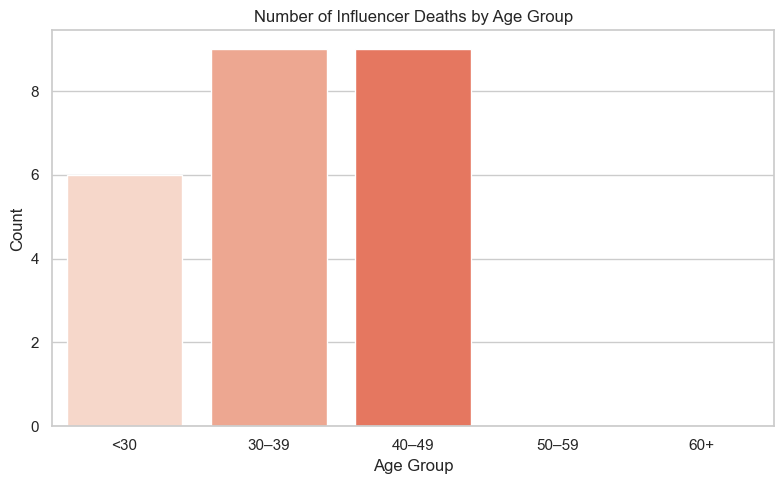

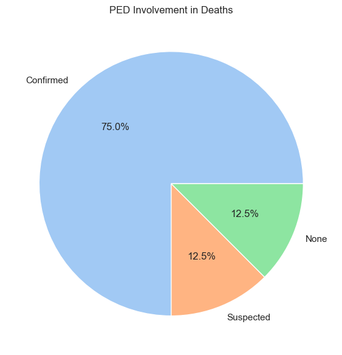

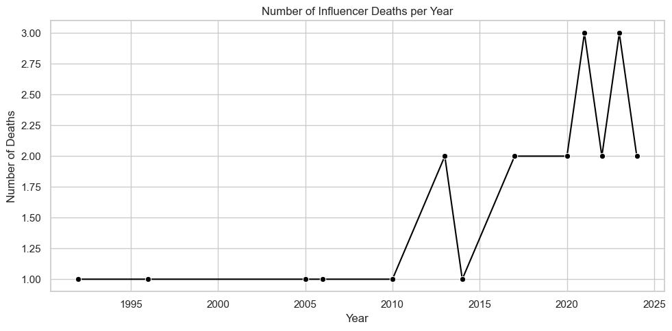

```python
import matplotlib.pyplot as plt
import seaborn as sns

# Set style
sns.set(style="whitegrid")

# --- Plot 1: Deaths by Age Group ---
plt.figure(figsize=(8, 5))
sns.countplot(data=influencer_df, x='Age Group', order=['<30', '30–39', '40–49', '50–59', '60+'], palette='Reds')
plt.title('Number of Influencer Deaths by Age Group')
plt.xlabel('Age Group')
plt.ylabel('Count')
plt.tight_layout()
plt.savefig('../visuals/deaths_by_age_group.png')
plt.show()

# --- Plot 2: PED Involvement Pie Chart ---
plt.figure(figsize=(6, 6))
ped_counts = influencer_df['PED Category'].value_counts()
plt.pie(ped_counts, labels=ped_counts.index, autopct='%1.1f%%', colors=sns.color_palette('pastel'))
plt.title('PED Involvement in Deaths')
plt.tight_layout()
plt.savefig('../visuals/ped_involvement_pie.png')
plt.show()

# Extract the year from the 'Date of Death' column
influencer_df['Year of Death'] = pd.to_datetime(influencer_df['Date of Death'], errors='coerce').dt.year


# --- Plot 3: Timeline of Deaths per Year ---
plt.figure(figsize=(10, 5))
yearly_deaths = influencer_df['Year of Death'].value_counts().sort_index()
sns.lineplot(x=yearly_deaths.index, y=yearly_deaths.values, marker='o', color='black')
plt.title('Number of Influencer Deaths per Year')
plt.xlabel('Year')
plt.ylabel('Number of Deaths')
plt.tight_layout()
plt.savefig('../visuals/deaths_per_year_timeline.png')
plt.show()
```

## 📊 Influencer Mortality Analysis

To quantify the real-world consequences of performance-enhancing drug culture in fitness, we analyzed a curated dataset of notable influencers and professional athletes who died prematurely.

### 1. Deaths by Age Group

The chart clearly shows that the **majority of deaths occurred between ages 30 and 49**, with a substantial number occurring even before 30. This is deeply concerning given these individuals were presumed to be in peak physical condition.

> 🔎 Insight: The pursuit of extreme aesthetics is claiming lives **well before the average life expectancy**, particularly in the early stages of adulthood.

### 2. PED Involvement Breakdown

The pie chart reveals that:

- **75% of deaths were confirmed PED users**
- An additional 12.5% were **suspected but unconfirmed**
- Only 12.5% had **no known connection** to enhancement drugs

> 💊 Insight: This validates the trend we observed earlier — PED usage isn't just correlated with extreme physiques; it's potentially linked to early mortality.

### 3. Deaths Over Time

The line plot demonstrates that fitness-related deaths have **accelerated post-2015**, coinciding with:

- The rise of influencer-based fitness marketing
- Increased accessibility to SARMs and steroids
- Normalization of PED use on platforms like YouTube, TikTok, and Reddit

> 📈 Insight: We're witnessing a **clear uptick in mortality in the social media era**, where aesthetic perfection is broadcasted, monetized, and often chemically enhanced.

These charts close the loop on a critical question:

> What happens when fitness stops being about health and becomes a high-stakes aesthetic competition?

The data speaks for itself.

# ✅ Notebook Summary: The Aesthetic Trap — From Trends to Tragedy

This notebook explored how the definition of "fitness" has shifted in modern culture — from health and performance to aesthetics and extremity.

### 💡 Final Insight:

> Fitness is no longer about living longer — it's about looking better, faster.

Social media, competitive culture, and chemical shortcuts have created a generation chasing an aesthetic standard that often comes at the cost of **health, transparency, and even life**.

### 🔜 What’s Next: Reddit NLP

In the next notebook, we’ll analyze Reddit discussions around:

- SARMs and steroids
- Body image anxiety
- “Natty vs not” debates
- Mental health in fitness communities

Using **natural language processing**, we’ll uncover what the public really thinks — and how social platforms are shaping the narrative.

➡️Let's dive deeper into the **psychology and discourse** behind this transformation.